# 10 - Tibbles

Augusto de Souza Cavalcanti

25/04/2021

## 10.1 Introduction

Tibbles são alterações dos dataframes. Vamos discutir o pacote tibble nesse capítulo (presente no tidyverse).

## 10.1 Creating Tibbles

Quase todas funções que usamos nessse livro produzem tibbles, dado que essas são a estrutura de dados mais comum no tidyverse. Mas muitos outros pacotes e dados usam dataframes. Então voce pode converter esses em tibbles.

```r
as_tibble(iris)
```

```
## # A tibble: 150 x 5
##    Sepal.Length Sepal.Width Petal.Length Petal.Width Species
##           <dbl>       <dbl>        <dbl>       <dbl> <fct>
##  1          5.1         3.5          1.4         0.2 setosa
##  2          4.9         3            1.4         0.2 setosa
##  3          4.7         3.2          1.3         0.2 setosa
##  4          4.6         3.1          1.5         0.2 setosa
##  5          5           3.6          1.4         0.2 setosa
##  6          5.4         3.9          1.7         0.4 setosa
##  7          4.6         3.4          1.4         0.3 setosa
##  8          5           3.4          1.5         0.2 setosa
##  9          4.4         2.9          1.4         0.2 setosa
## 10          4.9         3.1          1.5         0.1 setosa
## # ... with 140 more rows
```

Você pode criar tibbles a partir de vetores individuais. Inputs de tamanho 1 serão reciclados e variáveis podem ser a partir de referências as que acabaram de ser criadas.

```r
tibble(x=1:5,y=1,z = x**2+y,n = c('Guto','Bam','Bi','Norma','Ricardo'))
```

```
## # A tibble: 5 x 4
##       x     y     z n
##   <int> <dbl> <dbl> <chr>
## 1     1     1     2 Guto
## 2     2     1     5 Bam
## 3     3     1    10 Bi
## 4     4     1    17 Norma
## 5     5     1    26 Ricardo
```

Note que diferente de data.frame(), tibbles não alteram strings para fatores, nunca muda o nome de variáveis e nunca dão cria nomes para as linhas.

É possível que tibbles tenham nomes de colunas que não são válidas para nomes de variáveis no R. Para que isso aconteça elas devem vir cercadas de backsticks (`).

```r
tb <- tibble(`:)` = 'smile',` ` = 'space',`2000`='number')

tb
```

```
## # A tibble: 1 x 3
##   `:)`  ` `   `2000`
##   <chr> <chr> <chr>
## 1 smile space number
```

Quando estiver usando essas variáveis em outros pacotes também devem ser usados os backsticks. EVITAR CRIAR VARIÁVEIS DeSSA MANEIRA.

Outra maneira de criar tibbles é por meio do comando tribble que permite essa criação na maneira da leitura, para quantidades pequenas de dados é útil e o processo é feito com ~ para definir as colunas e , para separar os valores.

```r
tribble(~a,~b,~b2,
        #-#--#---#
        'oi',10,100,
        'ola',2,4,
        'tudo',3,9,
        'bem',7,49)
```

```
## # A tibble: 4 x 3
##   a         b    b2
##   <chr> <dbl> <dbl>
## 1 oi       10   100
## 2 ola       2     4
## 3 tudo      3     9
## 4 bem       7    49
```

## 10.3 Tibbles vs Data.Frame

Existem duas pricipais diferenças no uso de tibbles e data.frames classicos: Impressão e Subsetting.

### 10.3.1 Printing

Tibbles tem um metódo de impressão melhorado que só mostra as 10 primeiras linhas e a quantidade de colunas que cabem na tela. Isso torna a visualização melhor. Além disso cada coluna informa seu tipo, funcionalidade importada do comando str().

```r
tibble(
  a = lubridate::now() + runif(1e3) * 86400,
  b = lubridate::today() + runif(1e3) * 30,
  c = 1:1e3,
  d = runif(1e3),
  e = sample(letters, 1e3, replace = TRUE)
)
```

```
## # A tibble: 1,000 x 5
##    a                   b              c      d e
##    <dttm>              <date>     <int>  <dbl> <chr>
##  1 2021-08-11 23:28:17 2021-08-19     1 0.788  h
##  2 2021-08-12 20:05:23 2021-09-09     2 0.605  t
##  3 2021-08-12 12:53:02 2021-08-22     3 0.253  a
##  4 2021-08-12 17:59:57 2021-09-06     4 0.0614 l
##  5 2021-08-12 07:23:18 2021-09-08     5 0.584  h
##  6 2021-08-12 17:49:06 2021-08-16     6 0.119  y
##  7 2021-08-12 01:14:15 2021-08-25     7 0.983  y
##  8 2021-08-12 16:17:46 2021-08-13     8 0.434  k
##  9 2021-08-12 15:40:45 2021-08-31     9 0.672  z
## 10 2021-08-12 02:53:41 2021-09-03    10 0.115  n
## # ... with 990 more rows
```

Tibbles foram programadas para não sobrecarregar o sistema quando são pedidas grande impressões de dataframes. Mas as vezes é necessário imprimir mais dados que o pdarão e existem algumas maneiras de fazer isso.

Primeiro podemos pedir o print explicitamente e controlar o número de linhas que quer e a largura delas, width = inf vai mostrar todas colunas.

```r
voos <- nycflights13::flights

voos %>% print(n = 3)
```

```
## # A tibble: 336,776 x 19
##    year month   day dep_time sched_dep_time dep_delay arr_time sched_arr_time
##   <int> <int> <int>    <int>          <int>     <dbl>    <int>          <int>
## 1  2013     1     1      517            515         2      830            819
## 2  2013     1     1      533            529         4      850            830
## 3  2013     1     1      542            540         2      923            850
## # ... with 336,773 more rows, and 11 more variables: arr_delay <dbl>,
## #   carrier <chr>, flight <int>, tailnum <chr>, origin <chr>, dest <chr>,
## #   air_time <dbl>, distance <dbl>, hour <dbl>, minute <dbl>, time_hour <dttm>
```

Como estamos usando o rmarkdown o print já está otimizado e esses não alteram quando rodamos a chunk no rstudio.

Outra opção é usar view para abir esse dataframe no rstudio. Essa opção permite uma boa visualização e filtros úteis.

```r
# nycflights13::flights %>% View
```

### 10.3.2 Subsetting

Para fazer subsets precisamos sem o comando filter e select, precisamos usar $ e [[]]. Como o r padrão.

```r
xs <- tibble(x=2:10,x2 = x**2)

# Extrair pelo nome
xs$x
```

```
## [1]  2  3  4  5  6  7  8  9 10
```

```r
# ou
xs[["x"]]
```

```
## [1]  2  3  4  5  6  7  8  9 10
```

```r
# Extrair pela posição
xs[[2]]
```

```
## [1]   4   9  16  25  36  49  64  81 100
```

```r
xs[[1]][3] # Elemento 3 da coluna 1
```

```
## [1] 4
```

Para usar esse elementos em pipes é necessário usar um ponto antes deles.

```r
xs %>% .[[2]] %>% .[1]
```

```
## [1] 4
```

## 10.4 Interacting with Older Code

Algumas funções mais antigas não funcionam com tibbles, caso esse seja o caso temos que fazer as.data.frame() para que não ocorram erros.

## Exerícios 10.5

1. Como podemos saber se um objeto é uma tibble e não um data frame. Vamos usar mtcars de exemplo.

Podemos usar a função is_tibble para testar se é um tibble.

```r
is_tibble(mtcars)
```

```
## [1] FALSE
```

```r
is_tibble(diamonds)
```

```
## [1] TRUE
```

```r
is_tibble(nycflights13::flights)
```

```
## [1] TRUE
```

```r
is_tibble(as_tibble(mtcars))
```

```
## [1] TRUE
```

Existem diferenças também na impressão.

```r
mtcars %>% print()
```

```
##                      mpg cyl  disp  hp drat    wt  qsec vs am gear carb
## Mazda RX4           21.0   6 160.0 110 3.90 2.620 16.46  0  1    4    4
## Mazda RX4 Wag       21.0   6 160.0 110 3.90 2.875 17.02  0  1    4    4
## Datsun 710          22.8   4 108.0  93 3.85 2.320 18.61  1  1    4    1
## Hornet 4 Drive      21.4   6 258.0 110 3.08 3.215 19.44  1  0    3    1
## Hornet Sportabout   18.7   8 360.0 175 3.15 3.440 17.02  0  0    3    2
## Valiant             18.1   6 225.0 105 2.76 3.460 20.22  1  0    3    1
## Duster 360          14.3   8 360.0 245 3.21 3.570 15.84  0  0    3    4
## Merc 240D           24.4   4 146.7  62 3.69 3.190 20.00  1  0    4    2
## Merc 230            22.8   4 140.8  95 3.92 3.150 22.90  1  0    4    2
## Merc 280            19.2   6 167.6 123 3.92 3.440 18.30  1  0    4    4
## Merc 280C           17.8   6 167.6 123 3.92 3.440 18.90  1  0    4    4
## Merc 450SE          16.4   8 275.8 180 3.07 4.070 17.40  0  0    3    3
## Merc 450SL          17.3   8 275.8 180 3.07 3.730 17.60  0  0    3    3
## Merc 450SLC         15.2   8 275.8 180 3.07 3.780 18.00  0  0    3    3
## Cadillac Fleetwood  10.4   8 472.0 205 2.93 5.250 17.98  0  0    3    4
## Lincoln Continental 10.4   8 460.0 215 3.00 5.424 17.82  0  0    3    4
## Chrysler Imperial   14.7   8 440.0 230 3.23 5.345 17.42  0  0    3    4
## Fiat 128            32.4   4  78.7  66 4.08 2.200 19.47  1  1    4    1
## Honda Civic         30.4   4  75.7  52 4.93 1.615 18.52  1  1    4    2
## Toyota Corolla      33.9   4  71.1  65 4.22 1.835 19.90  1  1    4    1
## Toyota Corona       21.5   4 120.1  97 3.70 2.465 20.01  1  0    3    1
## Dodge Challenger    15.5   8 318.0 150 2.76 3.520 16.87  0  0    3    2
## AMC Javelin         15.2   8 304.0 150 3.15 3.435 17.30  0  0    3    2
## Camaro Z28          13.3   8 350.0 245 3.73 3.840 15.41  0  0    3    4
## Pontiac Firebird    19.2   8 400.0 175 3.08 3.845 17.05  0  0    3    2
## Fiat X1-9           27.3   4  79.0  66 4.08 1.935 18.90  1  1    4    1
## Porsche 914-2       26.0   4 120.3  91 4.43 2.140 16.70  0  1    5    2
## Lotus Europa        30.4   4  95.1 113 3.77 1.513 16.90  1  1    5    2
## Ford Pantera L      15.8   8 351.0 264 4.22 3.170 14.50  0  1    5    4
## Ferrari Dino        19.7   6 145.0 175 3.62 2.770 15.50  0  1    5    6
## Maserati Bora       15.0   8 301.0 335 3.54 3.570 14.60  0  1    5    8
## Volvo 142E          21.4   4 121.0 109 4.11 2.780 18.60  1  1    4    2
```

```r
mtcars %>% as_tibble() %>% print()
```

```
## # A tibble: 32 x 11
##      mpg   cyl  disp    hp  drat    wt  qsec    vs    am  gear  carb
##    <dbl> <dbl> <dbl> <dbl> <dbl> <dbl> <dbl> <dbl> <dbl> <dbl> <dbl>
##  1  21       6  160    110  3.9   2.62  16.5     0     1     4     4
##  2  21       6  160    110  3.9   2.88  17.0     0     1     4     4
##  3  22.8     4  108     93  3.85  2.32  18.6     1     1     4     1
##  4  21.4     6  258    110  3.08  3.22  19.4     1     0     3     1
##  5  18.7     8  360    175  3.15  3.44  17.0     0     0     3     2
##  6  18.1     6  225    105  2.76  3.46  20.2     1     0     3     1
##  7  14.3     8  360    245  3.21  3.57  15.8     0     0     3     4
##  8  24.4     4  147.    62  3.69  3.19  20       1     0     4     2
##  9  22.8     4  141.    95  3.92  3.15  22.9     1     0     4     2
## 10  19.2     6  168.   123  3.92  3.44  18.3     1     0     4     4
## # ... with 22 more rows
```

O print vai somente até 10 linhas e as colunas tem seus tipos informados. N colunas e linhas podem ser alterados como dito anteriormente.

2. Compare as seguintes operações em um dataframe e um tibble.

Data Frame:

```r
df <- data.frame(abc = 1, xyz = "a")
df$x
```

```
## [1] "a"
```

```r
df[, "xyz"]
```

```
## [1] "a"
```

```r
df[, c("abc", "xyz")]
```

```
##   abc xyz
## 1   1   a
```

Tibble:

```r
df <- tibble(abc = 1, xyz = "a")
df$x
```

[output not shown]

```r
df[, "xyz"]
```

```
## # A tibble: 1 x 1
##   xyz
##   <chr>
## 1 a
```

```r
df[, c("abc", "xyz")]
```

```
## # A tibble: 1 x 2
##     abc xyz
##   <dbl> <chr>
## 1     1 a
```

O data frame automaticamente completa o nome da coluna quando não fazemos por completo, isso pode causar problemas caso tenhamos muitas colunas, tibbl só faz a impressão do que foi pedido. Além as opreações com [] retonam um tibble mesmo que sejam de apenas uma coluna enquanto com o df retornam somente se tiverem 2 ou mais.

3. Se você tem o nome de uma variável em um objeto, como você pode selecionar a variável de um tibble?

```r
var <- 'drv'

mpg[,var]
```

```
## # A tibble: 234 x 1
##    drv
##    <chr>
##  1 f
##  2 f
##  3 f
##  4 f
##  5 f
##  6 f
##  7 f
##  8 4
##  9 4
## 10 4
## # ... with 224 more rows
```

```r
# ou
mpg[[var]]
```

```
##   [1] "f" "f" "f" "f" "f" "f" "f" "4" "4" "4" "4" "4" "4" "4" "4" "4" "4" "4"
##  [19] "r" "r" "r" "r" "r" "r" "r" "r" "r" "r" "4" "4" "4" "4" "f" "f" "f" "f"
##  [37] "f" "f" "f" "f" "f" "f" "f" "f" "f" "f" "f" "f" "4" "4" "4" "4" "4" "4"
##  [55] "4" "4" "4" "4" "4" "4" "4" "4" "4" "4" "4" "4" "4" "4" "4" "4" "4" "4"
##  [73] "4" "4" "r" "r" "r" "4" "4" "4" "4" "4" "4" "4" "4" "4" "4" "4" "4" "4"
##  [91] "r" "r" "r" "r" "r" "r" "r" "r" "r" "f" "f" "f" "f" "f" "f" "f" "f" "f"
## [109] "f" "f" "f" "f" "f" "f" "f" "f" "f" "f" "f" "f" "f" "f" "4" "4" "4" "4"
## [127] "4" "4" "4" "4" "4" "4" "4" "4" "r" "r" "r" "4" "4" "4" "4" "f" "f" "f"
## [145] "f" "f" "f" "f" "f" "f" "4" "4" "4" "4" "f" "f" "f" "f" "f" "4" "4" "4"
## [163] "4" "4" "4" "4" "4" "4" "4" "4" "4" "4" "4" "4" "4" "4" "4" "4" "4" "f"
## [181] "f" "f" "f" "f" "f" "f" "f" "f" "f" "f" "f" "f" "f" "f" "f" "f" "f" "f"
## [199] "4" "4" "4" "4" "4" "4" "4" "4" "4" "f" "f" "f" "f" "f" "f" "f" "f" "f"
## [217] "f" "f" "f" "f" "f" "f" "f" "f" "f" "f" "f" "f" "f" "f" "f" "f" "f" "f"
```

Não podemos usar $ pois ele considera o nome do que está sendo passado não o conteudo interno.

4. Practice referring to non-syntactic names in the following data frame by:

Extracting the variable called 1.

Plotting a scatterplot of 1 vs 2.

Creating a new column called 3 which is 2 divided by 1.

Renaming the columns to one, two and three.

```r
annoying <- tibble(
  `1` = 1:10,
  `2` = `1` * 2 + rnorm(length(`1`))
)
```

```r
annoying$`1`
```

```
##  [1]  1  2  3  4  5  6  7  8  9 10
```

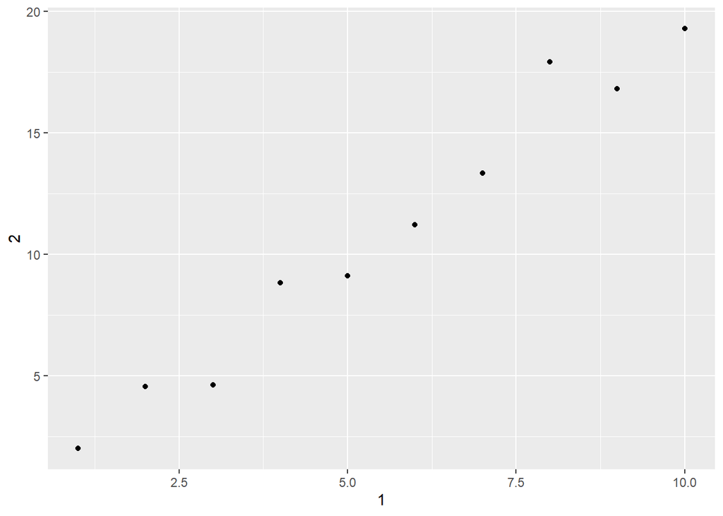

```r
ggplot(annoying,aes(x=`1`,y=`2`)) + geom_point()
```

```r
annoying <- annoying %>% mutate(`3`= `2` / `1`)
```

```r
annoying %>% rename('one' = `1`,'two'=`2`,three =`3`)
```

```
## # A tibble: 10 x 3
##      one   two three
##    <int> <dbl> <dbl>
##  1     1  2.01  2.01
##  2     2  4.56  2.28
##  3     3  4.63  1.54
##  4     4  8.83  2.21
##  5     5  9.12  1.82
##  6     6 11.2   1.87
##  7     7 13.3   1.91
##  8     8 17.9   2.24
##  9     9 16.8   1.87
## 10    10 19.3   1.93
```

5. O que tibble::enfame faz?

Enframe converte vetores nomeados ou listas em dataframes com nomes e valores:

```r
enframe(c(a=1,b=2,c=3))
```

```
## # A tibble: 3 x 2
##   name  value
##   <chr> <dbl>
## 1 a         1
## 2 b         2
## 3 c         3
```

6. O argumento n_extra determina quantas colunas do fundo da tibble são impressas.